# Factorial analysis

# $3^2$ factorial experiments analysis

```r
raw <- read.xlsx("G:/Documents/MS-Thesis-Pitt/Data-analysis/Spinning.xlsx",
                 sheetIndex = 2,
                 colClasses = NA)

raw <- filter(raw,bac_recovery != is.na(bac_recovery)) #bac_recovery>0.2)
raw$BR <- raw$bac_recovery*100
raw$Vol_out2in <- 1-raw$HCT_diluted/100/.85
raw$CR_rich <- raw$conc_recovery/raw$Vol_out2in

raw$Hold_time.num <- raw$Hold_time
raw$HCT_diluted.num <- raw$HCT_diluted
raw$Hold_time <- factor(x=raw$Hold_time)#,ordered=TRUE)
raw$HCT_diluted <- factor(x=raw$HCT_diluted)#,ordered=TRUE)


# calculate PR and RR <- pasted from "Spinning analysis.Rmd"
Temp = 23 #C
rho_PBS <- -5.2037e-6*Temp^2 - 8.1463e-6*Temp + 1.0097
# I got this correlation from
# (http://www.sciencedirect.com/science/article/pii/S003991400400373X)

raw$VolFracPlasma  <- with(raw,{VolWB*(1-HCT)/(VolWB*(1-HCT) + VolPBS)})
raw$RhoSolution    <- with(raw,{(rho_PBS*VolPBS + 1.024*(1-HCT)*VolWB)/(VolPBS + (1-HCT)*VolWB)})
raw$VFlowdown      <- with(raw,{gplas_tot/(RhoSolution*(1-HCT_plas)+1.093*HCT_plas)})

raw$RR <- with(raw,{VFlowdown*HCT_plas/(VolWB*HCT)*100})
raw$PR <- with(raw,{VFlowdown*(1-HCT_plas)/(VolPBS+VolWB*(1-HCT))*100})

# subset data (with or without outliers from linear models. Make sure to justify each remove in comments)
inliers <- raw[-c(11,39,41,21),]

# summarize results
raw.sum <- inliers %>%
  group_by(HCT_diluted,Hold_time)  %>%
  summarise(n=n(),
            BR.mean = mean(BR),BR.sd = sd(BR),
            PR.mean = mean(PR),PR.sd = sd(PR),
            RR.mean = mean(RR),RR.sd = sd(RR))
raw.sum
```

```
## # A tibble: 9 x 9
## # Groups:   HCT_diluted [3]
##   HCT_diluted Hold_time     n BR.mean BR.sd PR.mean PR.sd RR.mean RR.sd
##   <fct>       <fct>     <int>   <dbl> <dbl>   <dbl> <dbl>   <dbl> <dbl>
## 1 5           4             6    71.2 13.0     75.3  1.83   0     0
## 2 5           8             5    61.9 10.5     75.2  1.45   0.266 0.594
## 3 5           30            5    62.1 18.8     74.4  2.96   0     0
## 4 21          4             5    55.4 15.4     73.2  3.12   1.92  1.22
## 5 21          8             6    56.0 12.7     74.8  2.47   0.900 0.643
## 6 21          30            6    51.9  9.61    74.9  1.44   0     0
## 7 47          4             5    32.4  7.91    55.9  5.18  16.2   2.93
## 8 47          8             5    38.1  9.79    57.3  2.33  13.8   3.34
## 9 47          30            6    40.9  6.45    64.1  2.28   1.89  1.02
```

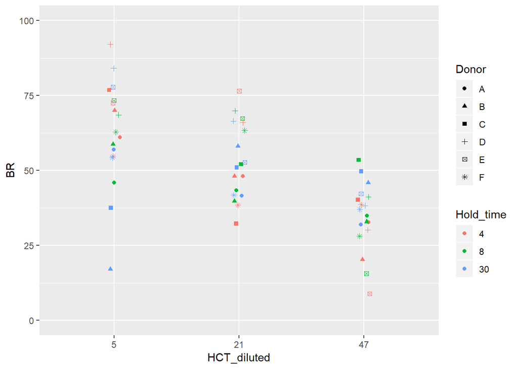

```r
ggplot(raw,aes(HCT_diluted,BR,color=Hold_time,shape=Donor))+geom_jitter(width=0.05)+ylim(ymin=0,ymax=100)
```

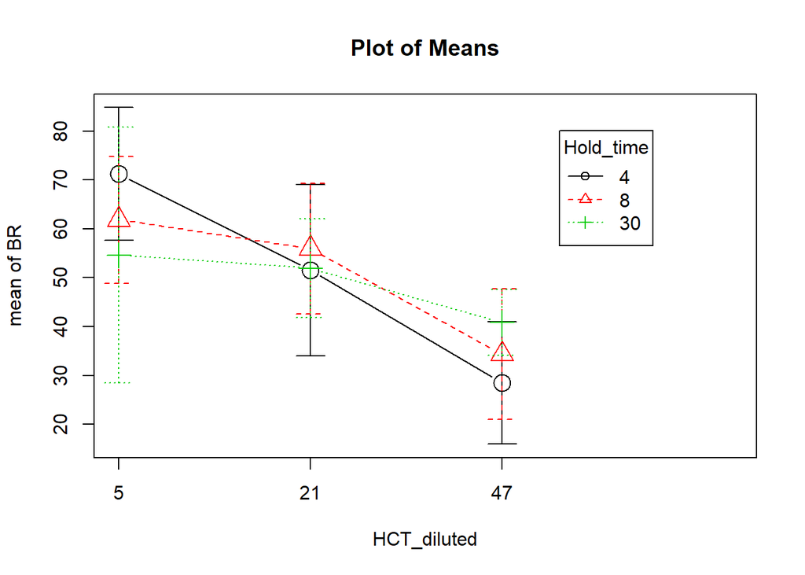

```r
with(raw,plotMeans(BR,HCT_diluted,Hold_time,error.bars='conf.int'))
```

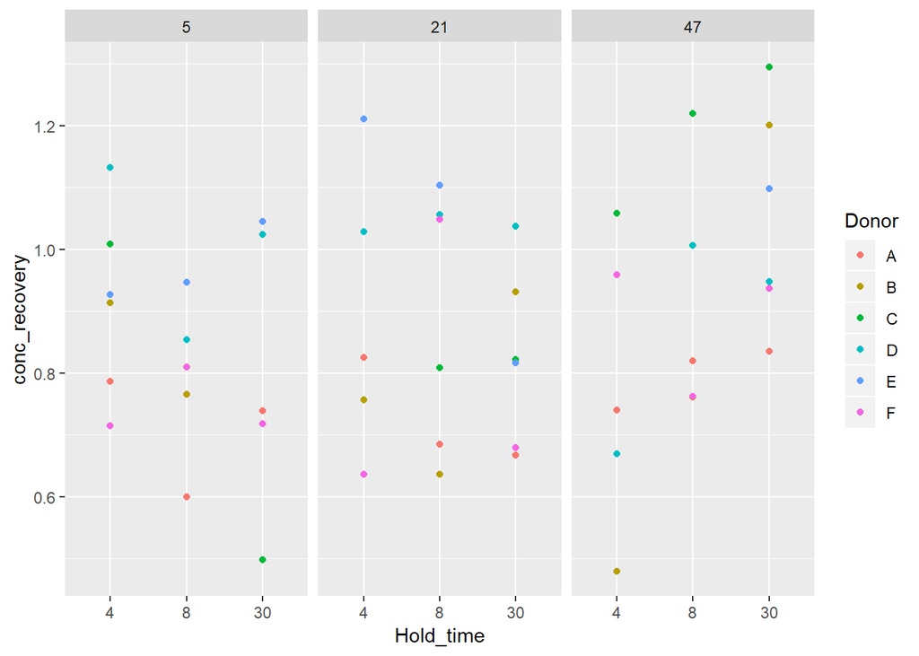

```r
ggplot(inliers,aes(Hold_time,conc_recovery,color=Donor))+geom_point()+facet_grid(.~HCT_diluted)
```

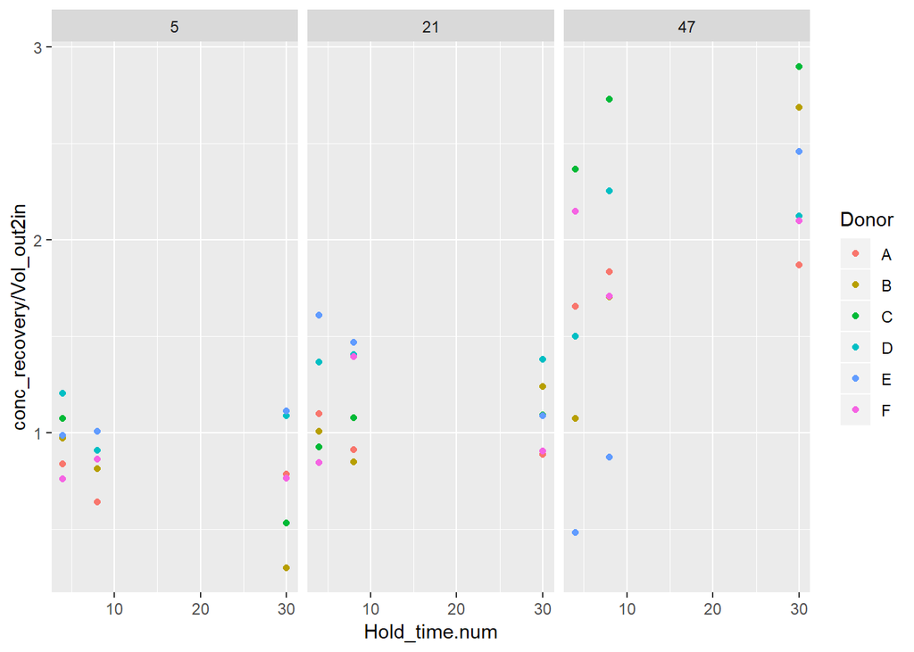

```r
ggplot(raw,aes(Hold_time.num,conc_recovery/Vol_out2in,color=Donor))+geom_point()+facet_grid(.~HCT_diluted)
```

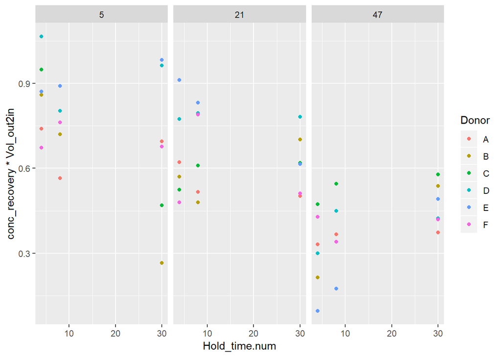

```r
ggplot(raw,aes(Hold_time.num,conc_recovery*Vol_out2in,color=Donor))+geom_point()+facet_grid(.~HCT_diluted)
```

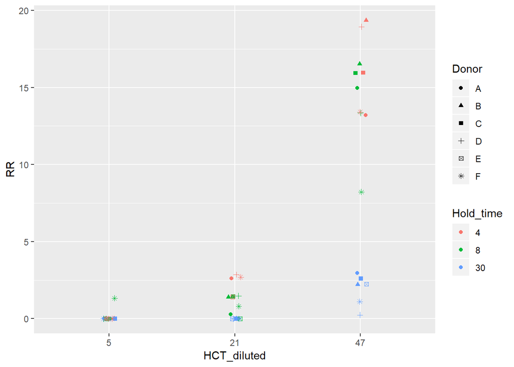

```r
ggplot(inliers,aes(HCT_diluted,RR,color=Hold_time,shape=Donor))+geom_jitter(width=0.05)
```

Red cell recovery decreases with as the cell pack compresses

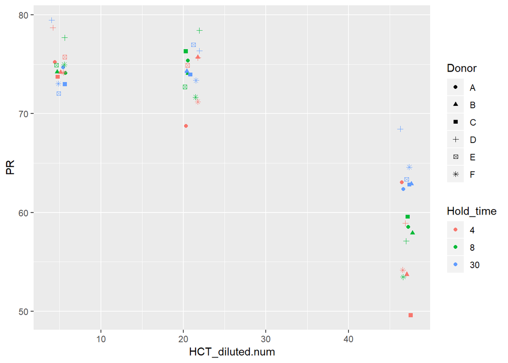

```r
ggplot(inliers,aes(HCT_diluted.num,PR,color=Hold_time,shape=Donor))+geom_jitter(width=1)
```

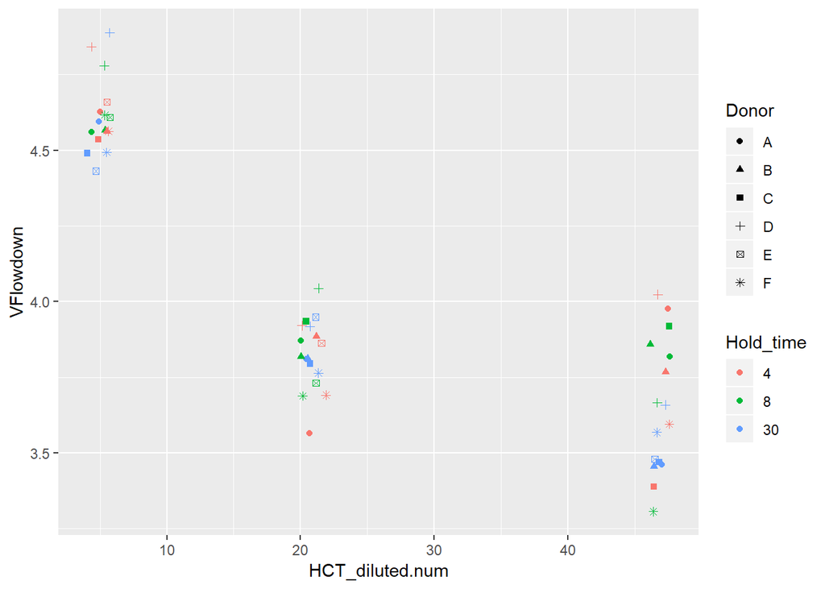

```r
ggplot(inliers,aes(HCT_diluted.num,VFlowdown,color=Hold_time,shape=Donor))+geom_jitter(width=1)
```

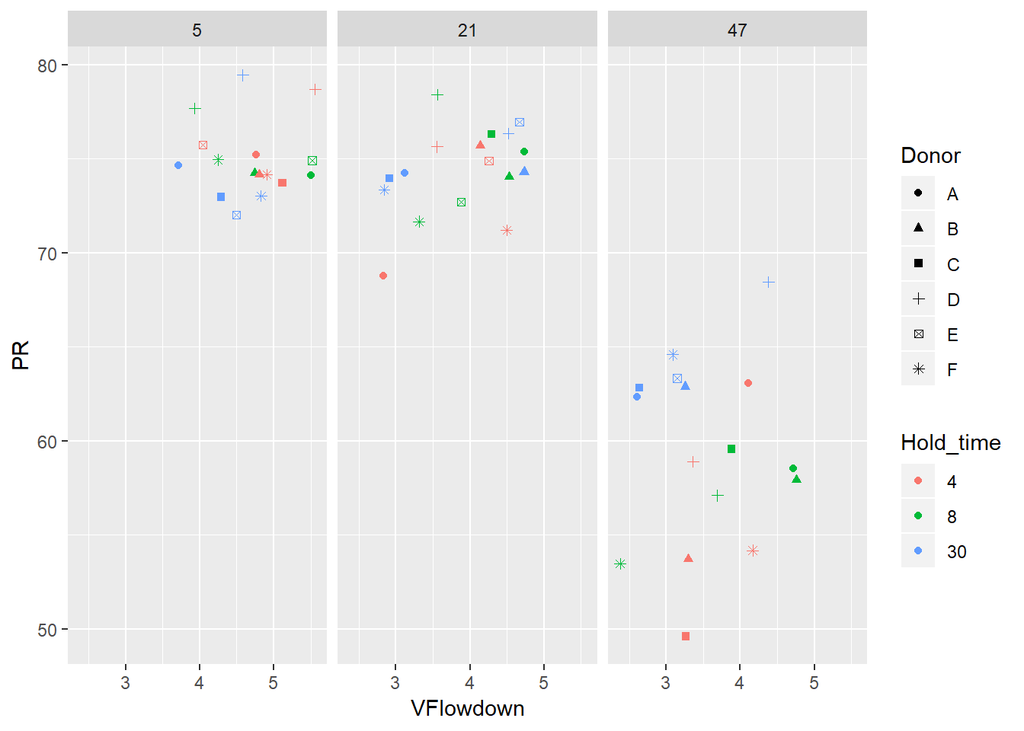

```r
ggplot(inliers,aes(VFlowdown,PR,color=Hold_time,shape=Donor))+geom_jitter(width=1)+facet_grid(.~HCT_diluted)
```

At H=5, time doesn’t seem to matter. As hematocrit increases, Plasma recovery increases with time because the cell pack compresses more.

Mashsa saw that plasma recovery was higher with short times. Potential reasons: > Matte disks do not dry as quickly >

At H=47, Plasma is undiluted, which increases the cost of trapped plasma. I need to revisit trough overflow for red cells.

#### Is it wettability or viscosity?

If wettability: Measure contact angle for dilutions of plasma-PBS If Viscosity: interpolate plas and PBS visc.

```r
BR.lm.i <- lm(BR~Hold_time*HCT_diluted+Donor,data=inliers); summary(BR.lm.i)
```

```
##
## Call:
## lm(formula = BR ~ Hold_time * HCT_diluted + Donor, data = inliers)
##
## Residuals:
##      Min       1Q   Median       3Q      Max
## -24.4268  -5.8578   0.9688   5.2290  13.6056
##
## Coefficients:
##                           Estimate Std. Error t value Pr(>|t|)
## (Intercept)                 62.723      4.962  12.640 1.32e-14 ***
## Hold_time8                  -9.180      5.913  -1.552 0.129554
## Hold_time30                -10.029      5.909  -1.697 0.098517 .
## HCT_diluted21              -15.616      5.913  -2.641 0.012276 *
## HCT_diluted47              -36.978      5.913  -6.253 3.59e-07 ***
## DonorB                       3.762      4.742   0.793 0.432968
## DonorC                       9.279      4.951   1.874 0.069297 .
## DonorD                      17.789      4.573   3.890 0.000429 ***
## DonorE                      17.576      4.951   3.550 0.001123 **
## DonorF                       2.514      4.573   0.550 0.585941
## Hold_time8:HCT_diluted21     9.548      8.417   1.134 0.264352
## Hold_time30:HCT_diluted21    6.383      8.348   0.765 0.449654
## Hold_time8:HCT_diluted47    14.891      8.521   1.747 0.089328 .
## Hold_time30:HCT_diluted47   16.659      8.348   1.996 0.053801 .
## ---
## Signif. codes:  0 '***' 0.001 '**' 0.01 '*' 0.05 '.' 0.1 ' ' 1
##
## Residual standard error: 9.701 on 35 degrees of freedom
## Multiple R-squared:  0.7416, Adjusted R-squared:  0.6456
## F-statistic: 7.727 on 13 and 35 DF,  p-value: 6.683e-07
```

```r
BR.lm.a <- lm(BR~Hold_time+HCT_diluted+Donor,data=raw); summary(BR.lm.a)
```

```
##
## Call:
## lm(formula = BR ~ Hold_time + HCT_diluted + Donor, data = raw)
##
## Residuals:
##     Min      1Q  Median      3Q     Max
## -37.942  -5.810   2.014   7.013  19.098
##
## Coefficients:
##               Estimate Std. Error t value Pr(>|t|)
## (Intercept)    56.8932     5.8377   9.746 1.87e-12 ***
## Hold_time8      0.4344     4.5931   0.095  0.92509
## Hold_time30    -1.2823     4.5167  -0.284  0.77785
## HCT_diluted21  -9.5260     4.5931  -2.074  0.04410 *
## HCT_diluted47 -28.1107     4.5931  -6.120 2.44e-07 ***
## DonorB         -0.6165     6.3876  -0.097  0.92356
## DonorC          6.7354     6.6018   1.020  0.31332
## DonorD         17.7885     6.3876   2.785  0.00793 **
## DonorE         10.0360     6.3876   1.571  0.12348
## DonorF          2.5144     6.3876   0.394  0.69579
## ---
## Signif. codes:  0 '***' 0.001 '**' 0.01 '*' 0.05 '.' 0.1 ' ' 1
##
## Residual standard error: 13.55 on 43 degrees of freedom
## Multiple R-squared:  0.544,  Adjusted R-squared:  0.4486
## F-statistic:   5.7 on 9 and 43 DF,  p-value: 3.534e-05
```

```r
Anova(BR.lm.i,type=2)
```

```
## Anova Table (Type II tests)
##
## Response: BR
##                       Sum Sq Df F value    Pr(>F)
## Hold_time               52.6  2  0.2797  0.757691
## HCT_diluted           5516.6  2 29.3069 3.332e-08 ***
## Donor                 2471.4  5  5.2518  0.001061 **
## Hold_time:HCT_diluted  486.0  4  1.2910  0.292367
## Residuals             3294.1 35
## ---
## Signif. codes:  0 '***' 0.001 '**' 0.01 '*' 0.05 '.' 0.1 ' ' 1
```

```r
pwr.f2.test(u=13,sig.level=0.01,f2=0.64/(1-0.64),power=0.99)
```

```
##
##      Multiple regression power calculation
##
##               u = 13
##               v = 25.87582
##              f2 = 1.777778
##       sig.level = 0.01
##           power = 0.99
```

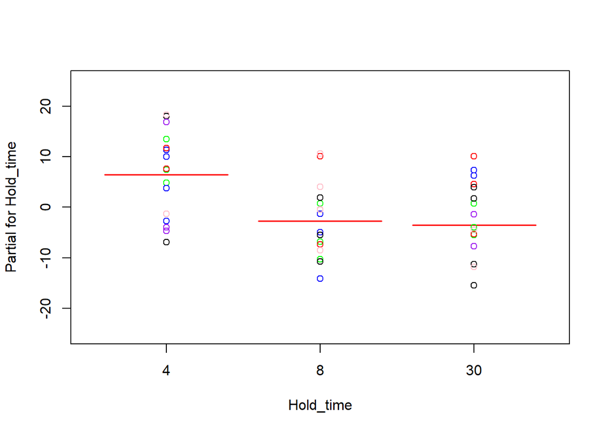

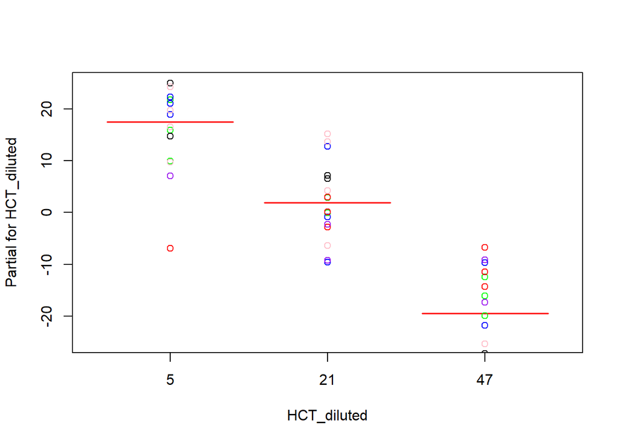

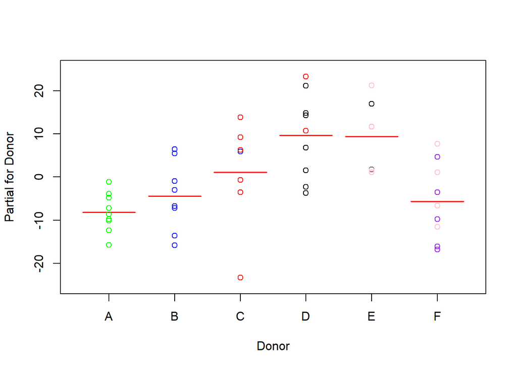

```r
termplot(BR.lm.i,partial.resid = TRUE,ask=FALSE,col.res =c('green','blue','red','black','pink','purple')[raw$Donor],ylim = c(-25,25))
```

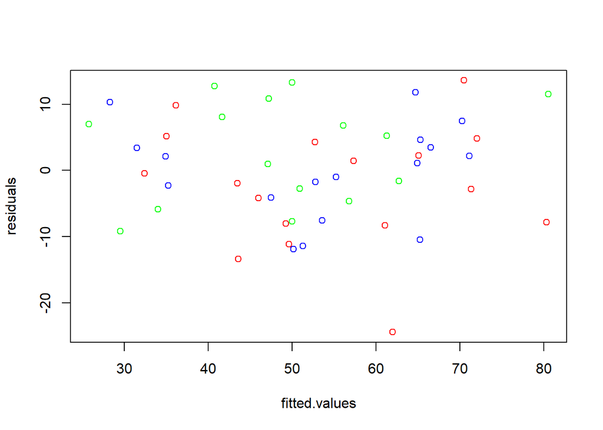

```r
with(BR.lm.i,plot(fitted.values,residuals,col=c('green','blue','red')[as.numeric(raw$Hold_time)]))
```

## Commentary From partial residual plots, the donor makes a big difference.

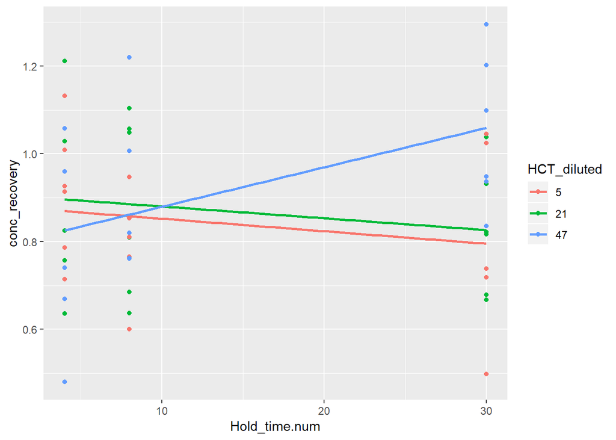

```r
ggplot(inliers,aes(Hold_time.num,conc_recovery,color=HCT_diluted))+geom_point()+geom_smooth(method='lm',se=F)
```

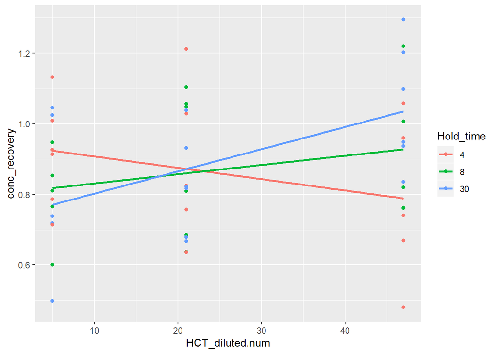

```r
ggplot(inliers,aes(HCT_diluted.num,conc_recovery,color=Hold_time))+geom_point()+geom_smooth(method='lm',se=F)
```

```r
CR.lm.poly  <- lm(conc_recovery~Hold_time*HCT_diluted+Donor,
             data=inliers,
             contrasts=list(Hold_time='contr.poly',
                            HCT_diluted='contr.poly',
                            Donor='contr.sum'))
summary(CR.lm.poly)
```

```
##
## Call:
## lm(formula = conc_recovery ~ Hold_time * HCT_diluted + Donor,
##     data = inliers, contrasts = list(Hold_time = "contr.poly",
##         HCT_diluted = "contr.poly", Donor = "contr.sum"))
##
## Residuals:
##      Min       1Q   Median       3Q      Max
## -0.35950 -0.09202  0.00560  0.08867  0.23639
##
## Coefficients:
##                            Estimate Std. Error t value Pr(>|t|)
## (Intercept)                0.881633   0.023498  37.520  < 2e-16 ***
## Hold_time.L                0.008825   0.040475   0.218  0.82866
## Hold_time.Q                0.001618   0.040689   0.040  0.96850
## HCT_diluted.L              0.068928   0.041427   1.664  0.10508
## HCT_diluted.Q              0.009583   0.040178   0.239  0.81288
## Donor1                    -0.137389   0.050100  -2.742  0.00955 **
## Donor2                    -0.087522   0.053108  -1.648  0.10830
## Donor3                     0.069986   0.056667   1.235  0.22505
## Donor4                     0.091386   0.050100   1.824  0.07669 .
## Donor5                     0.137843   0.056667   2.433  0.02025 *
## Hold_time.L:HCT_diluted.L  0.184846   0.069948   2.643  0.01222 *
## Hold_time.Q:HCT_diluted.L -0.029974   0.072232  -0.415  0.68069
## Hold_time.L:HCT_diluted.Q  0.080048   0.070106   1.142  0.26128
## Hold_time.Q:HCT_diluted.Q  0.026357   0.069369   0.380  0.70627
## ---
## Signif. codes:  0 '***' 0.001 '**' 0.01 '*' 0.05 '.' 0.1 ' ' 1
##
## Residual standard error: 0.1626 on 35 degrees of freedom
## Multiple R-squared:  0.4743, Adjusted R-squared:  0.279
## F-statistic: 2.429 on 13 and 35 DF,  p-value: 0.0184
```

```r
# I need to either research polynomial contrasts more, or else convert time and HCT to continuous.
# maybe I need to center these. How can I look at VIF?
CR.lm.num <- lm(conc_recovery~Donor+Hold_time.num*HCT_diluted.num,data=raw)
summary(CR.lm.num)
```

```
##
## Call:
## lm(formula = conc_recovery ~ Donor + Hold_time.num * HCT_diluted.num,
##     data = raw)
##
## Residuals:
##      Min       1Q   Median       3Q      Max
## -0.54271 -0.12076  0.01113  0.10429  0.35058
##
## Coefficients:
##                                 Estimate Std. Error t value Pr(>|t|)
## (Intercept)                    0.8653425  0.0998870   8.663  4.6e-11 ***
## DonorB                         0.0033889  0.0972226   0.035  0.97235
## DonorC                         0.1854260  0.1003339   1.848  0.07132 .
## DonorD                         0.2287749  0.0972226   2.353  0.02315 *
## DonorE                         0.1173245  0.0972226   1.207  0.23397
## DonorF                         0.0630854  0.0972226   0.649  0.51979
## Hold_time.num                 -0.0100239  0.0042640  -2.351  0.02328 *
## HCT_diluted.num               -0.0058078  0.0026011  -2.233  0.03070 *
## Hold_time.num:HCT_diluted.num  0.0004713  0.0001424   3.310  0.00187 **
## ---
## Signif. codes:  0 '***' 0.001 '**' 0.01 '*' 0.05 '.' 0.1 ' ' 1
##
## Residual standard error: 0.2062 on 44 degrees of freedom
## Multiple R-squared:  0.3209, Adjusted R-squared:  0.1974
## F-statistic: 2.599 on 8 and 44 DF,  p-value: 0.02027
```

```r
Anova(CR.lm.num,type=2)
```

```
## Anova Table (Type II tests)
##
## Response: conc_recovery
##                                Sum Sq Df F value   Pr(>F)
## Donor                         0.39612  5  1.8626 0.120456
## Hold_time.num                 0.01575  1  0.3704 0.545938
## HCT_diluted.num               0.01183  1  0.2780 0.600641
## Hold_time.num:HCT_diluted.num 0.46604  1 10.9566 0.001868 **
## Residuals                     1.87154 44
## ---
## Signif. codes:  0 '***' 0.001 '**' 0.01 '*' 0.05 '.' 0.1 ' ' 1
```

Significant positive linear interaction between hold time and hematocrit.

for facet_grid(Hold_Time~.): At low hold time, increasing the hematocrit decreases the concentration recovery. At high hold time, increasing the hematocrit increases the concentration recovery.

At low hematocrit, increasing hold time decreases concentration recovery At high hematocrit,increasing hold time increases concentration recovery > More plasma backflow

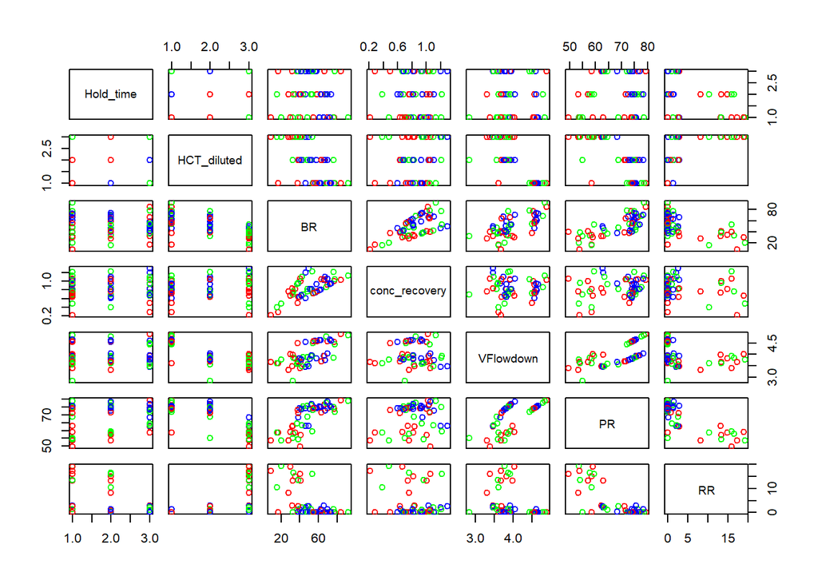

```r
pairs(dplyr::select(raw,c(Hold_time,HCT_diluted,BR,conc_recovery,VFlowdown,PR,RR)),
      col = c('blue','green','red')[inliers$HCT_diluted])
```

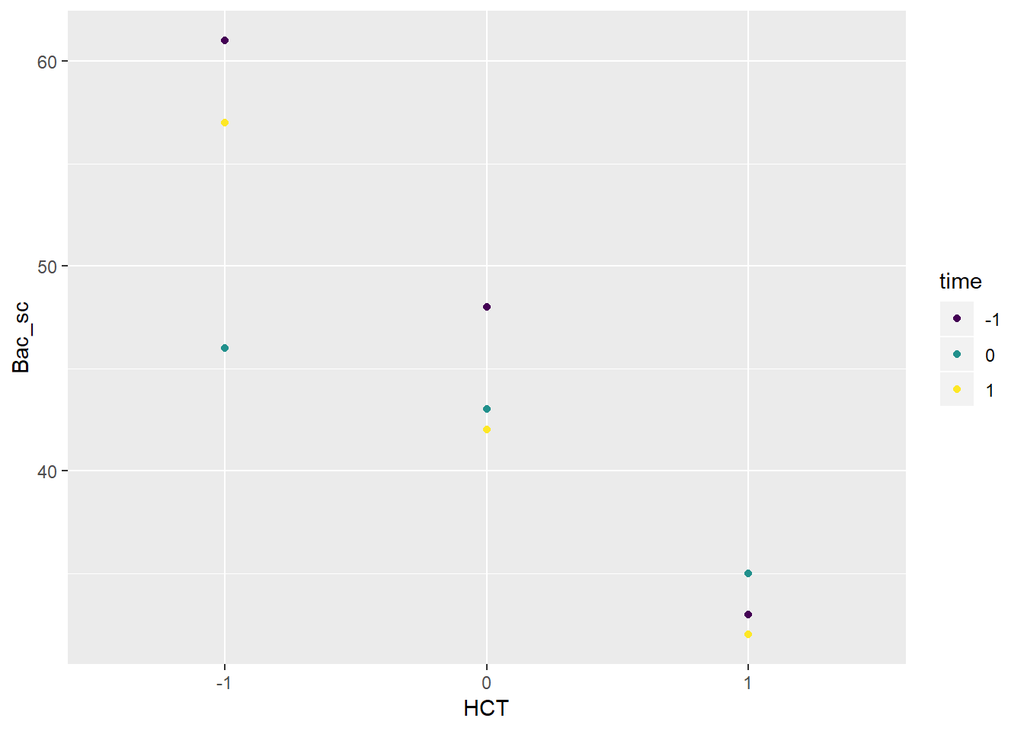

```r
HCT = factor(c(1,0,1,-1,0,-1,-1,0,1),ordered=TRUE)
time= factor(c(0,-1,-1,-1,1,0,1,0,1),ordered=TRUE)
Bac_sc = c(35,48,33,61,42,46,57,43,32)
Bac_mc = c(35,44,35,63,41,44,61,38,35)
df <- data.frame(HCT=HCT,
                 time=time,
                 Bac_sc=Bac_sc,
                 Bac_mc=Bac_mc)

ggplot(df,aes(HCT,Bac_sc,color=time))+geom_point()
```

```r
BR.lm <- lm(Bac_sc ~ time+HCT,data=df);summary(BR.lm)
```

```
##
## Call:
## lm(formula = Bac_sc ~ time + HCT, data = df)
##
## Residuals:
##       1       2       3       4       5       6       7       8       9
##  4.4444  0.4444 -3.5556  3.1111 -1.8889 -5.8889  2.7778  1.4444 -0.8889
##
## Coefficients:
##             Estimate Std. Error t value Pr(>|t|)
## (Intercept)  44.1111     1.5909  27.728 1.01e-05 ***
## time.L       -2.5927     2.7555  -0.941  0.40001
## time.Q        3.4021     2.7555   1.235  0.28453
## HCT.L       -15.0849     2.7555  -5.475  0.00542 **
## HCT.Q        -0.2722     2.7555  -0.099  0.92607
## ---
## Signif. codes:  0 '***' 0.001 '**' 0.01 '*' 0.05 '.' 0.1 ' ' 1
##
## Residual standard error: 4.773 on 4 degrees of freedom
## Multiple R-squared:  0.8901, Adjusted R-squared:  0.7802
## F-statistic: 8.098 on 4 and 4 DF,  p-value: 0.03359
```